# Working with Genomic Ranges

This section introduces two useful packages for general-purpose work on genomic coordinates. The rtracklayer package provides the `import()` function to read many types of genomic files (e.g., BED, GTF, VCF, FASTA) into *Bioconductor* objects. The GenomicRanges package provides functions for manipulating genomic ranges, i.e., descriptions of exons, genes, ChIP peaks, called variants, … as coordinates in genome space.

Start by attaching the rtracklayer and GenomicRanges packages to our session.

```r
library("rtracklayer")
library("GenomicRanges")
```

**Importing data**

We’ll read in a BED file derived from the UCSC genome browser. The file contains the coordinates of all CpG islands in the human genome, and is described at the UCSC table browser. Here are the first few lines of the file, giving the chromosme, start and end coordinates, and identifier of each CpG island.

```
chr1    155188536   155192004   CpG:_361
chr1    2226773 2229734 CpG:_366
chr1    36306229    36307408    CpG:_110
chr1    47708822    47710847    CpG:_164
chr1    53737729    53739637    CpG:_221
chr1    144179071   144179313   CpG:_20
```

Use `file.choose()` to find the file

```r
fname <- file.choose()   # CpGislands.Hsapiens.hg38.UCSC.bed
```

```r
fname
```

```
## [1] "files/CpGislands.Hsapiens.hg38.UCSC.bed"
```

```r
file.exists(fname)
```

```
## [1] TRUE
```

Then use `import()` from rtracklayer to read the data into *R*. The end result is a `GenomicRanges` object describing each CpG island.

```r
cpg <- import(fname)
cpg
```

```
## GRanges object with 30477 ranges and 1 metadata column:
##                          seqnames              ranges strand |        name
##                             <Rle>           <IRanges>  <Rle> | <character>
##       [1]                    chr1 155188537-155192004      * |    CpG:_361
##       [2]                    chr1     2226774-2229734      * |    CpG:_366
##       [3]                    chr1   36306230-36307408      * |    CpG:_110
##       [4]                    chr1   47708823-47710847      * |    CpG:_164
##       [5]                    chr1   53737730-53739637      * |    CpG:_221
##       ...                     ...                 ...    ... .         ...
##   [30473] chr22_KI270734v1_random       131010-132049      * |    CpG:_102
##   [30474] chr22_KI270734v1_random       161257-161626      * |     CpG:_55
##   [30475] chr22_KI270735v1_random         17221-18098      * |    CpG:_100
##   [30476] chr22_KI270738v1_random           4413-5280      * |     CpG:_80
##   [30477] chr22_KI270738v1_random           6226-6467      * |     CpG:_34
##   -------
##   seqinfo: 254 sequences from an unspecified genome; no seqlengths
```

Closely compare the coordinates of the first few ranges from the file with the first few ranges in the *Bioconductor* representation. The [BED format](https://genome.ucsc.edu/FAQ/FAQformat.html#format1) specification says that coordinates are 0-based, and intervals are half-open (the ‘start’ coordinate is in the range, the ‘end’ coordinate is immediately after the range; this makes some computations easy). *Bioconductor*’s convention is that coordinates are 1-based and closed (i.e., both start and end coordinates are included in the range). rtracklayer’s `import()` function has adjusted coordinates to follow *Bioconductor* conventions.

**Working with genomic ranges**

For convenience and to illustrate functionality, let’s work only with the ‘standard’ chromosomes 1 - 22 autosomal, X, and Y chromosomes. Look up the help page `?keepStandardChromosomes` for an explanation of `pruning.mode=`.

```r
cpg <- keepStandardChromosomes(cpg, pruning.mode = "coarse")
cpg
```

```
## GRanges object with 27949 ranges and 1 metadata column:
##           seqnames              ranges strand |        name
##              <Rle>           <IRanges>  <Rle> | <character>
##       [1]     chr1 155188537-155192004      * |    CpG:_361
##       [2]     chr1     2226774-2229734      * |    CpG:_366
##       [3]     chr1   36306230-36307408      * |    CpG:_110
##       [4]     chr1   47708823-47710847      * |    CpG:_164
##       [5]     chr1   53737730-53739637      * |    CpG:_221
##       ...      ...                 ...    ... .         ...
##   [27945]    chr22   50704375-50704880      * |     CpG:_38
##   [27946]    chr22   50710878-50711294      * |     CpG:_41
##   [27947]    chr22   50719959-50721632      * |    CpG:_180
##   [27948]    chr22   50730600-50731304      * |     CpG:_65
##   [27949]    chr22   50783345-50783889      * |     CpG:_63
##   -------
##   seqinfo: 24 sequences from an unspecified genome; no seqlengths
```

There are two parts to a `GenomicRanges` object. The `seqnames` (chromosomes, in the present case), start and end coordinates, and strand are *required*. Additional elements such as `name` in the current example are optional. Required components are accessed by functions such as `start()`, `end()` and `width()`. Optional components can be accessed using the `$` notation.

```r
head( start(cpg) )
```

```
## [1] 155188537   2226774  36306230  47708823  53737730 144179072
```

```r
head( cpg$name )
```

```
## [1] "CpG:_361" "CpG:_366" "CpG:_110" "CpG:_164" "CpG:_221" "CpG:_20"
```

Use the `width()` accessor function to extract a vector of widths of each CpG island. Transform the values using `log10()`, and visualize the distribution using `hist()`.

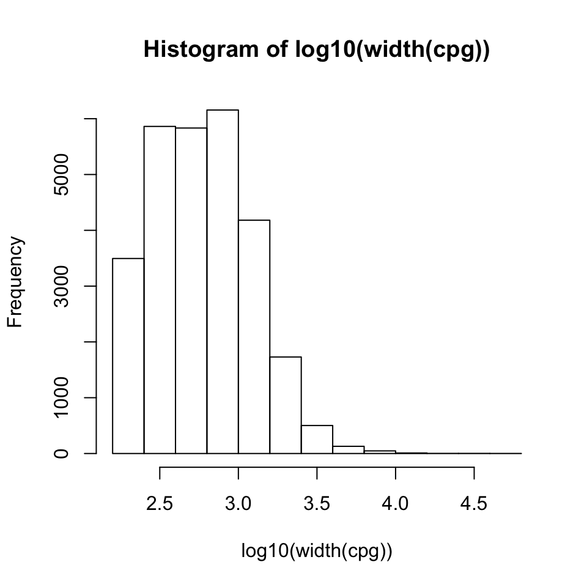

```r
hist(log10(width(cpg)))
```

Use `subset()` to select the CpG islands on chromosomes 1 and 2.

```r
subset(cpg, seqnames %in% c("chr1", "chr2"))
```

```
## GRanges object with 4217 ranges and 1 metadata column:
##          seqnames              ranges strand |        name
##             <Rle>           <IRanges>  <Rle> | <character>
##      [1]     chr1 155188537-155192004      * |    CpG:_361
##      [2]     chr1     2226774-2229734      * |    CpG:_366
##      [3]     chr1   36306230-36307408      * |    CpG:_110
##      [4]     chr1   47708823-47710847      * |    CpG:_164
##      [5]     chr1   53737730-53739637      * |    CpG:_221
##      ...      ...                 ...    ... .         ...
##   [4213]     chr2 242003256-242004412      * |     CpG:_79
##   [4214]     chr2 242006590-242010686      * |    CpG:_263
##   [4215]     chr2 242045491-242045723      * |     CpG:_16
##   [4216]     chr2 242046615-242047706      * |    CpG:_170
##   [4217]     chr2 242088150-242089411      * |    CpG:_149
##   -------
##   seqinfo: 24 sequences from an unspecified genome; no seqlengths
```

**Genomic annotations**

Earlier we mentioned ‘Annotation data’ packages. An example is the TxDb family of packages. These packages contain information on the genomic coordinates of exons, genes, transcripts, etc. Attach the TxDb package corresponding to the *Homo sapiens* hg38 genome build using the UCSC ‘knownGene’ track.

```r
library("TxDb.Hsapiens.UCSC.hg38.knownGene")
```

Extract the coordinates of all transcripts

```r
tx <- transcripts(TxDb.Hsapiens.UCSC.hg38.knownGene)
tx
```

```
## GRanges object with 226811 ranges and 2 metadata columns:
##                    seqnames        ranges strand |     tx_id
##                       <Rle>     <IRanges>  <Rle> | <integer>
##        [1]             chr1   11869-14409      + |         1
##        [2]             chr1   12010-13670      + |         2
##        [3]             chr1   29554-31097      + |         3
##        [4]             chr1   30267-31109      + |         4
##        [5]             chr1   30366-30503      + |         5
##        ...              ...           ...    ... .       ...
##   [226807] chrUn_GL000220v1 155997-156149      + |    226807
##   [226808] chrUn_KI270442v1 380608-380726      + |    226808
##   [226809] chrUn_KI270442v1 217250-217401      - |    226809
##   [226810] chrUn_KI270744v1   51009-51114      - |    226810
##   [226811] chrUn_KI270750v1 148668-148843      + |    226811
##                      tx_name
##                  <character>
##        [1] ENST00000456328.2
##        [2] ENST00000450305.2
##        [3] ENST00000473358.1
##        [4] ENST00000469289.1
##        [5] ENST00000607096.1
##        ...               ...
##   [226807] ENST00000619779.1
##   [226808] ENST00000620265.1
##   [226809] ENST00000611690.1
##   [226810] ENST00000616830.1
##   [226811] ENST00000612925.1
##   -------
##   seqinfo: 595 sequences (1 circular) from hg38 genome
```

Keep only the standard chromosomes, to work smoothly with our `cpg` object.

```r
tx <- keepStandardChromosomes(tx, pruning.mode="coarse")
tx
```

```
## GRanges object with 206694 ranges and 2 metadata columns:
##            seqnames      ranges strand |     tx_id           tx_name
##               <Rle>   <IRanges>  <Rle> | <integer>       <character>
##        [1]     chr1 11869-14409      + |         1 ENST00000456328.2
##        [2]     chr1 12010-13670      + |         2 ENST00000450305.2
##        [3]     chr1 29554-31097      + |         3 ENST00000473358.1
##        [4]     chr1 30267-31109      + |         4 ENST00000469289.1
##        [5]     chr1 30366-30503      + |         5 ENST00000607096.1
##        ...      ...         ...    ... .       ...               ...
##   [206690]     chrM   5826-5891      - |    206690 ENST00000387409.1
##   [206691]     chrM   7446-7514      - |    206691 ENST00000387416.2
##   [206692]     chrM 14149-14673      - |    206692 ENST00000361681.2
##   [206693]     chrM 14674-14742      - |    206693 ENST00000387459.1
##   [206694]     chrM 15956-16023      - |    206694 ENST00000387461.2
##   -------
##   seqinfo: 25 sequences (1 circular) from hg38 genome
```

**Overlaps**

A very useful operation is to count overlaps in two distinct genomic ranges objects. The following counts the number of CpG islands that overlap each transcript. Related functions include `findOverlaps()`, `nearest()`, `precede()`, and `follow()`.

```r
olaps <- countOverlaps(tx, cpg)
length(olaps)     # 1 count per transcript
```

```
## [1] 206694
```

```r
table(olaps)
```

```
## olaps
##      0      1      2      3      4      5      6      7      8      9
## 111952  76053  11809   3494   1458    684    394    253    169     92
##     10     11     12     13     14     15     16     17     18     19
##     66     40     43     30     22     20     20      7     14      7
##     20     21     22     23     24     25     26     27     28     29
##      7      3      7      6      3      1      4      1      3      1
##     30     31     32     33     34     35     36     37     38     63
##      6      5      3      3      1      2      3      1      1      4
##     65     71
##      1      1
```

Calculations such as `countOverlaps()` can be added to the `GRanges` object, tightly coupling derived data with the original annotation.

```r
tx$cpgOverlaps <- countOverlaps(tx, cpg)
tx
```

```
## GRanges object with 206694 ranges and 3 metadata columns:
##            seqnames      ranges strand |     tx_id           tx_name
##               <Rle>   <IRanges>  <Rle> | <integer>       <character>
##        [1]     chr1 11869-14409      + |         1 ENST00000456328.2
##        [2]     chr1 12010-13670      + |         2 ENST00000450305.2
##        [3]     chr1 29554-31097      + |         3 ENST00000473358.1
##        [4]     chr1 30267-31109      + |         4 ENST00000469289.1
##        [5]     chr1 30366-30503      + |         5 ENST00000607096.1
##        ...      ...         ...    ... .       ...               ...
##   [206690]     chrM   5826-5891      - |    206690 ENST00000387409.1
##   [206691]     chrM   7446-7514      - |    206691 ENST00000387416.2
##   [206692]     chrM 14149-14673      - |    206692 ENST00000361681.2
##   [206693]     chrM 14674-14742      - |    206693 ENST00000387459.1
##   [206694]     chrM 15956-16023      - |    206694 ENST00000387461.2
##            cpgOverlaps
##              <integer>
##        [1]           0
##        [2]           0
##        [3]           1
##        [4]           0
##        [5]           0
##        ...         ...
##   [206690]           0
##   [206691]           0
##   [206692]           0
##   [206693]           0
##   [206694]           0
##   -------
##   seqinfo: 25 sequences (1 circular) from hg38 genome
```

It is then possible to perform coordinated actions, e.g., subsetting the `GRanges` objects for transcripts satisfying particular conditions, in a coordinated fashion where the software does all the book-keeping to makes sure the correct ranges are selected.

```r
subset(tx, cpgOverlaps > 10)
```

```
## GRanges object with 270 ranges and 3 metadata columns:
##         seqnames            ranges strand |     tx_id           tx_name
##            <Rle>         <IRanges>  <Rle> | <integer>       <character>
##     [1]     chr1   2050470-2185395      + |       263 ENST00000378567.7
##     [2]     chr1   2050485-2146108      + |       264 ENST00000468310.5
##     [3]     chr1   2073462-2185390      + |       269 ENST00000400921.6
##     [4]     chr1   2073986-2185190      + |       271 ENST00000461106.6
##     [5]     chr1   3069168-3434342      + |       352 ENST00000511072.5
##     ...      ...               ...    ... .       ...               ...
##   [266]     chrX 40051246-40177329      - |    203175 ENST00000378455.8
##   [267]     chrX 40051248-40177329      - |    203177 ENST00000342274.8
##   [268]     chrX 40062955-40177320      - |    203180 ENST00000406200.2
##   [269]     chrY     333963-386710      - |    206258 ENST00000390665.8
##   [270]     chrY     344896-386955      - |    206264 ENST00000445792.7
##         cpgOverlaps
##           <integer>
##     [1]          15
##     [2]          11
##     [3]          13
##     [4]          13
##     [5]          32
##     ...         ...
##   [266]          11
##   [267]          11
##   [268]          11
##   [269]          14
##   [270]          12
##   -------
##   seqinfo: 25 sequences (1 circular) from hg38 genome
```

Can you think of other situations where one might calculate derived values and couple these with `GRanges` or similar objects?

**Exercise (10 min)**

What is the maximum number of exons per transcript on chromosome 1 of the hg38 genome assembly?

Hints:

1. The `exons` function extracts exon coordinates from a TxDb object.
2. The `exons` function has an argument `columns` that can be used to obtain the transcript ID (`tx_id`) and/or transcript name (`tx_name`) for each exon.